# SVM

AUTEUR Celeste Esteban

2023-11-30

## Un SVM, mais pour quoi faire ?

Le SVM (Support Vector Machine ou Machine à vecteurs de support) est un **algorithme d’apprentissage automatique supervisé** qui peut être utilisé pour résoudre des problèmes de **classification** ou de régression.

Le principe des SVM consiste à ramener un problème de classification ou de discrimination à un hyperplan (feature space) dans lequel les données sont séparées en plusieurs classes, la frontière de séparation étant la plus éloignée possible des points de données (ou marge maximale).

Prenons un exemple simple de classification pour mieux comprendre de quoi il s’agit. Supposons une population composée de 50% de femmes et 50% d’hommes. En utilisant un échantillon de cette population, nous souhaitons créer un ensemble de règles à partir de variables quantitatives (taille, poids, etc) qui nous guideront dans la classification des sexes pour le reste de la population.

## Chargement des données :

**TOUTES LES DONNÉES ONT ÉTÉ ANONYMISÉES ET NE CONTIENNENT AUCUNE DONNÉE A CARACTÈRE PERSONNEL, ET LEURS CONFORMITÉ AU RGPD EST ASSURÉE**  
*Une donnée à caractère personnel est une information qui permet d’identifier un être humain (personne physique), directement (par exemple son nom/prénom), ou indirectement (par exemple son numéro de téléphone, son numéro de contrat, son pseudonyme).*

On importe les données depuis un fichier CSV. La fonction *“dimension”* nous apprend que le jeu de données contient **20 variables** pour **610 lignes**.

```r
BVCM = read.csv2(file = "BVCM.csv", header = TRUE, sep = ';', dec = '.', stringsAsFactors = FALSE)
```

```
## [1] 610  20
```

Le jeu de données provient d’une base de données comprenant des informations sur les victimes corporelles médianes des sociétés opérant dans le domaine de l’assurance. Plus précisément, chaque ligne correspond au dossier d’une **victime d’un accident domestique ou de la route**, pour lequel les deux marques cherchent à **évaluer puis indemniser les préjudices** subis par la victime. À chaque dossier est associé un montant en euros, résultant de calculs complexes. Selon les dossiers, le montant total peut mettre plusieurs mois, voire même des années, avant d’être validé. En effet, ces calculs nécessitent une connaissance approfondie d’une grande quantité d’informations concernant la victime. De plus, certaines données nécessaires au calcul de l’indemnisation peuvent varier avec le temps et **demandent beaucoup de temps** pour se stabiliser.

En sachant cela, mon objectif ici est de “prédire” le montant d’un dossier en **se basant sur les informations les plus accessibles** à la société d’assurance, celles qui nous sont connues dans les premières semaines suivant l’accident de la victime. Dans ce projet j’ai créé deux classes basées sur le montant des dossiers :

- Un dossier est **“pas cher”** si son montant est inférieur ou égal à 150 000 euros
- Un dossier est **“cher”** si son montant est supérieur à 150 000 euros

Les données quantitatives qui serviront à construire notre SVM sont les suivantes :

- *Rente_V* : Euros de rente viagère liée au dossier
- *Rente_T* : Euros de rente temporaire liée au dossier
- *Age* : Âge à l’accident de la victime
- *Revenu* : Revenu annuel net de la victime avant l’accident
- *AIPP* : Taux d’atteinte permanente à l’intégrité physique et/ou psychique de la victime après l’accident
- *Arret* : Nombre de jours d’arrêt de travail actuel de la victime

## Analyse des Correspondances Multiples :

Afin d’accroître la précision de notre modèle SVM, nous allons incorporer les variables qualitatives de notre jeu de données. Pour ce faire, nous allons effectuer une Analyse des Correspondances Multiples (ACM). Tout comme l’Analyse en Composantes Principales (ACP), l’ACM nous permettra de créer des dimensions récapitulatives du jeu de données, d’observer des regroupements d’individus, et de déterminer quelles variables contribuent le plus à la variabilité. Cependant, ce qui revêt une importance particulière dans ce contexte est que l’ACM transforme un jeu de données qualitatif en un jeu de données quantitatif. Ainsi, les résultats de l’ACM nous serviront à alimenter le modèle d’apprentissage SVM.

Le résultat de l’ACM se traduit par la création de coordonnées pour les modalités de nos variables qualitatives en entrée sur 8 dimensions. Pour visualiser cela, voici un graphique où les coordonnées des nouvelles variables sur les dimensions 1 et 2 sont représentées, et la couleur indique la correspondance aux différentes modalités.

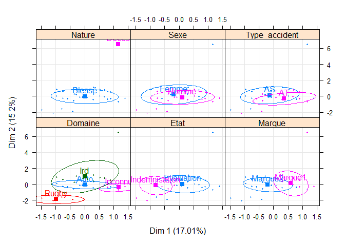

> La dimension 1 et 2 semble permettre de séparer les modalités sur la majorités des variables.

## Visualisation de nos données :

```
##  [1] "Dim 1"         "Dim 2"         "Dim 3"         "Dim 4"
##  [5] "Dim 5"         "Dim 6"         "Dim 7"         "Dim 8"
##  [9] "Rente _V"      "Rente _T"      "Age"           "Revenu"
## [13] "AIPP"          "Arret"         "Consolidation"
```

Pour chaque variable, nous allons examiner leurs caractéristiques et leurs répartitions à partir des éléments ci-dessous. Cela s’inscrit dans une démarche de compréhension de nos variables, afin que plus tard nous puissions construire notre modèle SVM en toute connaissance :

- La valeur minimum
- La valeur du premier quantile
- La médiane
- La moyenne
- Le troisième quartile
- La valeur maximum

```
##      Dim 1           Dim 2          Dim 3           Dim 4           Dim 5
##  Min.   :-1.47   Min.   :-2.1   Min.   :-0.34   Min.   :-1.27   Min.   :-0.65
##  1st Qu.:-0.29   1st Qu.:-0.2   1st Qu.:-0.13   1st Qu.:-0.24   1st Qu.:-0.31
##  Median :-0.08   Median :-0.1   Median :-0.13   Median :-0.09   Median :-0.08
##  Mean   : 0.00   Mean   : 0.0   Mean   : 0.00   Mean   : 0.00   Mean   : 0.00
##  3rd Qu.: 0.30   3rd Qu.: 0.2   3rd Qu.: 0.08   3rd Qu.: 0.30   3rd Qu.: 0.16
##  Max.   : 1.38   Max.   : 6.5   Max.   : 4.25   Max.   : 3.80   Max.   : 3.35
##      Dim 6           Dim 7            Dim 8          Rente _V     Rente _T
##  Min.   :-1.14   Min.   :-1.131   Min.   :-1.04   Min.   : 0   Min.   : 0
##  1st Qu.:-0.08   1st Qu.:-0.231   1st Qu.:-0.14   1st Qu.:28   1st Qu.: 9
##  Median : 0.07   Median : 0.004   Median :-0.03   Median :38   Median :19
##  Mean   : 0.00   Mean   : 0.000   Mean   : 0.00   Mean   :39   Mean   :21
##  3rd Qu.: 0.23   3rd Qu.: 0.179   3rd Qu.: 0.16   3rd Qu.:51   3rd Qu.:33
##  Max.   : 6.17   Max.   : 2.808   Max.   : 1.15   Max.   :92   Max.   :61
##       Age         Revenu           AIPP        Arret      Consolidation
##  Min.   : 0   Min.   :0e+00   Min.   : 0   Min.   :   0   Min.   :    3
##  1st Qu.:26   1st Qu.:1e+04   1st Qu.:10   1st Qu.:   0   1st Qu.:  546
##  Median :40   Median :2e+04   Median :15   Median : 246   Median :  731
##  Mean   :40   Mean   :2e+04   Mean   :18   Mean   : 389   Mean   : 1339
##  3rd Qu.:51   3rd Qu.:2e+04   3rd Qu.:22   3rd Qu.: 637   3rd Qu.: 1109
##  Max.   :92   Max.   :2e+05   Max.   :50   Max.   :2878   Max.   :16467
```

Dans le cadre de notre démarche visant à comprendre nos variables, nous créons des histogrammes pour représenter la répartition des individus pour chacune de nos variables :

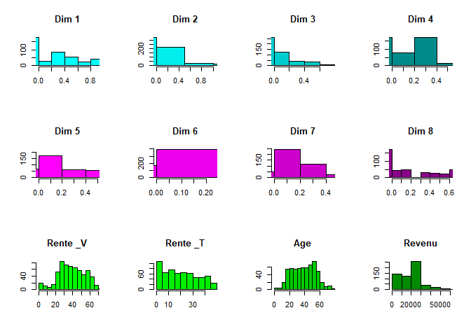

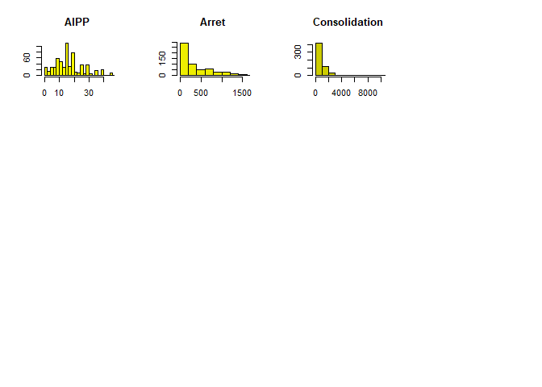

Enfin on réalise ces diagrammes en boîtes à moustache de chaque variable en fonction du montant total binaire du dossier (Cher ou Pas Cher). Une fois de plus cela nous permet de mieux comprendre nos données afin de réaliser le modèle le plus performant possible.

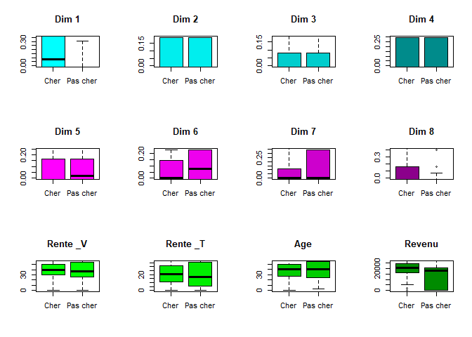

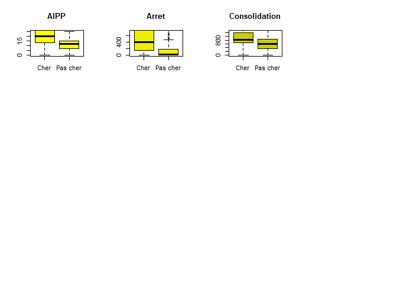

La séparation de la population en deux selon si le dossier a coûté *“Cher”* (montant supérieur à 150k euros) ou *“Pas Cher”* (montant inférieur à 150k euros) nous permet de détecter des corrélations. Par exemple, la variable AIPP se comporte différemment selon le coût du dossier. En effet, la valeur de l’AIPP est plus élevée en moyenne lorsque le dossier est “Cher”. Veuillez consulter l’Analyse en Composantes Principales (ACP) sur ces mêmes variables, disponible aussi sur mon GitHub.

## 1er modèle SVM à partir de la totalité des individus :

```
##
## Call:
## svm.default(x = BVCMQuanti, y = BVCMQualiMontant, scale = F, kernel = "radial",
##     degree = 1, coef0 = 1, cost = 1, probability = TRUE)
##
##
## Parameters:
##    SVM-Type:  C-classification
##  SVM-Kernel:  radial
##        cost:  1
##
## Number of Support Vectors:  607
```

Les paramètres choisis pour ce premier modèle SVM sont les suivants :

- Noyau = “radial” : Notre cas semble être difficile à séparer linéairement. On opte ici pour un noyau radial.
- Scale = “F” : Pour que nos individus ne soient utilisés qu’une fois dans l’apprentissage
- Cost = “1” : Le coût des violations de contrainte permet de plus ou moins sanctionner les individus mal classés.
- Coef0 = “1” Ici 1 (qui est le paramètre par défaut) offre de bonnes performances.

L’indice *“number of support vectors”* doit être petit par rapport au nombre d’individus. Un nombre de support vectors égale ou proche du nombre d’individus signifie que chaque individu a été sur-appris et aucune généralisation n’est possible.

En effet, si les données d’apprentissage sont trop “bien” apprises, alors notre modèle n’aura aucune performance face à de nouveaux individus qu’il n’aura jamais rencontrés. Ici le nombre de support vectors est de 607 (pour 610 individus).

Maintenant que le modèle est entraîné, nous allons le tester sur le même jeu de données et mesurer sa performance de prédiction à travers une matrice de confusion. L’exercice ici consiste pour le modèle à reprendre chaque individu en “cachant” le montant du dossier. C’est-à-dire qu’il ne dispose que des 15 variables paramètres du modèle pour prédire si le dossier est *“Cher”* ou *“Pas Cher”*. Une fois qu’il a prédit le montant de tous les dossiers, nous allons comparer le montant réel du dossier avec celui qu’il avait prédit.

```r
CM1$table
```

```
##           Reference
## Prediction Cher Pas cher
##   Cher      386        0
##   Pas cher    0      224
```

Le tableau se lit comme suit :

|  | Cher | Pas Cher |
| --- | --- | --- |
| Cher | Nb dossiers réellement Cher prédits Cher | Nb dossiers réellement Pas Cher prédits Cher |
| Pas Cher | Nb dossiers réellement Cher prédits Pas Cher | Nb dossiers réellement Pas Cher prédits Pas Cher |

Par exemple, ici il y a 386 dossiers réellement *“Cher”* prédit comme *“Cher”* par notre modèle. En revanche, 224 dossiers réellement *“Pas chers”* ont été classés par notre modèle comme *“Pas Cher”*.

Pour mesurer la performance de notre modèle regardons le pourcentage d’individus bien classé par rapport aux nombre de mal classés noté *“Accuracy”*:

```
##       Accuracy          Kappa  AccuracyLower  AccuracyUpper   AccuracyNull
##   1.000000e+00   1.000000e+00   9.939709e-01   1.000000e+00   6.327869e-01
## AccuracyPValue  McnemarPValue
##  5.848662e-122            NaN
```

Ici l’*“Accuracy”* du modèle est égale 1.

Notre modèle prédit correctement la classe de prix de 100% des dossiers ! C’est un excellent résultat, voir même un peu trop…

La démarche que je viens de vous exposer comporte une **faille**. Et c’est la suivante : **Les données qui servent à entraîner le modèle et les données qui servent à le tester sont les mêmes.** Après avoir pris conscience de ça, notre modèle perd en magie… Et oui, puisqu’on voudrait le féliciter d’avoir deviné la classe de prix des dossiers qu’il avait déjà vus lors de son apprentissage. On peut au moins le féliciter d’avoir une bonne mémoire, mais pas de pouvoir prédire et généraliser ses connaissances !  
**Mais ne pouvons-nous pas aller plus loin ?** Et bien si ! La bonne nouvelle, c’est qu’il existe une super technique pour éviter le sur-apprentissage et pour tester notre modèle sur des données qui lui sont inconnues, ce qui nous permettra de le tester en conditions réelles et de voir quelles sont ses performances face à de vrais dossiers.

Et pour cela, rien de mieux que le hasard…

## 2ème modèle SVM à partir d’une portion des individus connus :

Cette deuxième méthode est bien plus réaliste et permettra de faire preuve de robustesse face aux nouveaux individus.

On commence par créer une liste de 500 valeurs aléatoires comprise entre 1 et 610 (le nombre de lignes de notre jeu de données).

```r
Valeuralea =sample(size=500,1:610)
```

Ces 500 valeurs aléatoires vont nous permettre d’extraire du jeu de données initial 500 individus pris aléatoirement (par exemple le 2, le 5, le 7, le 8 etc). Ces 500 individus tirés au hasard vont constituer nos données d’entraînement. Le modèle vas se construire à partir de ses 500 individus et on le testera sur les 610 - 500 c’est à dire les 110 individus restants.

```
##
## Call:
## svm.default(x = Apprentissage_BVCMQuanti, y = Apprentissage_BVCMQualiMontant$Apprentissage_BVCMQualiMontant,
##     scale = F, kernel = "polynomial", degree = 1, coef0 = 1, cost = 1,
##     probability = TRUE)
##
##
## Parameters:
##    SVM-Type:  C-classification
##  SVM-Kernel:  polynomial
##        cost:  1
##      degree:  1
##      coef.0:  1
##
## Number of Support Vectors:  156
```

Maintenant que notre nouveau modèle est entraîné, nous allons effectuer les prédictions des montants sur les 110 dossiers restants, tous inconnus pour lui :

```r
Prediction2 <- predict(model_alea1,Test_BVCMQuanti,decision.values = TRUE)
```

Comme précédemment, nous pouvons mesurer la performance de notre modèle à travers une matrice de confusion :

```r
CM2$table
```

```
##           Reference
## Prediction Cher Pas cher
##   Cher       58       15
##   Pas cher    7       30
```

Pour mesurer la performance de notre modèle regardons le pourcentage d’individus bien classé par rapport aux nombre de mal classés noté *“Accuracy”*:

```
##       Accuracy          Kappa  AccuracyLower  AccuracyUpper   AccuracyNull
##   8.000000e-01   5.746924e-01   7.130049e-01   8.702115e-01   5.909091e-01
## AccuracyPValue  McnemarPValue
##   2.634847e-06   1.355930e-01
```

Ici l’*“Accuracy”* du modèle est égale 0.8

Notre modèle prédit correctement la classe de prix de 80% des dossiers !

C’est un **bon résultat**, bien que ce soit moins que les 100% du modèle précédent, mais ce second modèle est en réalité **bien meilleur** car il est testé avec des dossiers qu’il n’a pas appris.

Voici ce qui pourrait tout de même amélioré la précision du modèle :

- Inclure des variables qui expliquent encore mieux le montant total du dossier
- Le choix du noyau
- Le choix du coût de violation des contraintes
- Le choix des paramètres du noyau
- AUgmenter le volume d’apprentissage

## Visualisation de nos résultats :

Les individus colorés en rouges sont ceux prédits *“Pas cher”*. La première matrice de graphiques colore les points selon leur vrai montant. La secondes selon la prédiction de leurs montants par notre modèle.

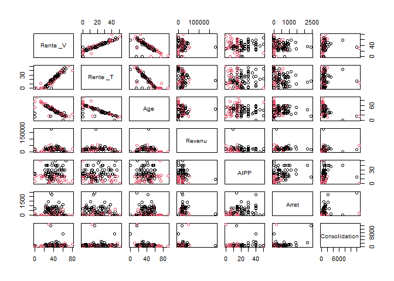

```r
plot(Test_BVCMQuanti[,9:15],col=Test_BVCMQualiMontant)
```

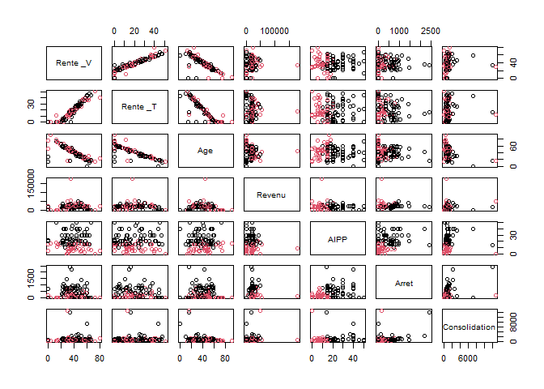

```r
plot(Test_BVCMQuanti[,9:15],col=Prediction2)
```

> Les dossiers “Pas cher” sont marqués par la couleur rouge.

On observe immédiatement l’émergence de groupes distincts séparant les dossiers “Cher” et “Pas cher”. Il est notable que notre modèle accentue l’appartenance à ces groupes, ce qui est normal puisque ce sont ces mêmes groupes qui lui permettent de prédire le montant du dossier. Il a tendance à généraliser en se basant sur ces patterns.

Pour conclure, nous avons identifié des corrélations directes entre les variables qui influent sur le montant des dossiers. Ces corrélations sont essentielles pour la création d’un modèle de prédiction. Comme démontré, notre modèle SVM est capable de prédire correctement la classe du montant d’un dossier dans 80% des cas. Bien que ce soit un résultat prometteur, l’idéal serait d’atteindre une précision plus élevée, par exemple 90%.

Cependant, il est important de noter que la méthode SVM ne semble pas permettre d’obtenir des résultats supérieurs. D’autres algorithmes d’apprentissage pourraient potentiellement offrir de meilleures performances. Je pense notamment aux réseaux de neurones, que je prévois de mettre en œuvre prochainement pour comparer la précision des modèles.

## Application de prédiction :

[Lien vers mon application SVM](https://celeste-esteban.shinyapps.io/app1/)